# Full-code Version (1)

### Objective

The food aggregator company has stored the data of the different orders made by the registered customers in their online portal. They want to analyze the data to get a fair idea about the demand of different restaurants which will help them in enhancing their customer experience. Suppose you are hired as a Data Scientist in this company and the Data Science team has shared some of the key questions that need to be answered. Perform the data analysis to find answers to these questions that will help the company to improve the business.

### Importing the required libraries

```python
# import libraries for data manipulation
import numpy as np
import pandas as pd

# import libraries for data visualization
import matplotlib.pyplot as plt
import seaborn as sns
```

### Understanding the structure of the data

```python
foodhub=pd.read_csv("foodhub_order.csv")
```

```python
foodhub.head(5) # Displays first 5 rows of the data
```

|  | order_id | customer_id | restaurant_name | cuisine_type | cost_of_the_order | day_of_the_week | rating | food_preparation_time | delivery_time |
| --- | --- | --- | --- | --- | --- | --- | --- | --- | --- |
| 0 | 1477147 | 337525 | Hangawi | Korean | 30.75 | Weekend | Not given | 25 | 20 |
| 1 | 1477685 | 358141 | Blue Ribbon Sushi Izakaya | Japanese | 12.08 | Weekend | Not given | 25 | 23 |
| 2 | 1477070 | 66393 | Cafe Habana | Mexican | 12.23 | Weekday | 5 | 23 | 28 |
| 3 | 1477334 | 106968 | Blue Ribbon Fried Chicken | American | 29.20 | Weekend | 3 | 25 | 15 |
| 4 | 1478249 | 76942 | Dirty Bird to Go | American | 11.59 | Weekday | 4 | 25 | 24 |

### **Question 1:** How many rows and columns are present in the data?

```python
foodhub.shape #Displays total no of rows of columns
```

```
(1898, 9)
```

#### Observations:

The dataset has 1898 rows and 9 columns.

### **Question 2:** What are the datatypes of the different columns in the dataset?

```python
foodhub.dtypes #Displays the datatypes of all the columns
```

```
order_id                   int64
customer_id                int64
restaurant_name           object
cuisine_type              object
cost_of_the_order        float64
day_of_the_week           object
rating                    object
food_preparation_time      int64
delivery_time              int64
dtype: object
```

```python
foodhub.info() #Displays the datatypes of all the columns along with the no of elements in each row.
```

```
<class 'pandas.core.frame.DataFrame'>
RangeIndex: 1898 entries, 0 to 1897
Data columns (total 9 columns):
 #   Column                 Non-Null Count  Dtype
---  ------                 --------------  -----
 0   order_id               1898 non-null   int64
 1   customer_id            1898 non-null   int64
 2   restaurant_name        1898 non-null   object
 3   cuisine_type           1898 non-null   object
 4   cost_of_the_order      1898 non-null   float64
 5   day_of_the_week        1898 non-null   object
 6   rating                 1898 non-null   object
 7   food_preparation_time  1898 non-null   int64
 8   delivery_time          1898 non-null   int64
dtypes: float64(1), int64(4), object(4)
memory usage: 133.6+ KB
```

#### Observations:

1.order_id,customer_id,food_preparation_time,delivery_time are integer dataype.  
2. restaurant_name,cuisine_type,day_of_the_week,rating are string datatype.  
3.cost_of_the_order is float datatype.

### **Question 3:** Are there any missing values in the data?

```python
foodhub.isnull().sum()  #displays the sum of null values
```

```
order_id                 0
customer_id              0
restaurant_name          0
cuisine_type             0
cost_of_the_order        0
day_of_the_week          0
rating                   0
food_preparation_time    0
delivery_time            0
dtype: int64
```

#### Observations:

There are no missing values in the data.

### **Question 4:** Check the statistical summary of the data. What is the minimum, average, and maximum time it takes for food to be prepared once an order is placed?

```python
foodhub.describe().T #displays statistics for numeric columns and T will Swaps rows and columns
```

|  | count | mean | std | min | 25% | 50% | 75% | max |
| --- | --- | --- | --- | --- | --- | --- | --- | --- |
| order_id | 1898.0 | 1.477496e+06 | 548.049724 | 1476547.00 | 1477021.25 | 1477495.50 | 1.477970e+06 | 1478444.00 |
| customer_id | 1898.0 | 1.711685e+05 | 113698.139743 | 1311.00 | 77787.75 | 128600.00 | 2.705250e+05 | 405334.00 |
| cost_of_the_order | 1898.0 | 1.649885e+01 | 7.483812 | 4.47 | 12.08 | 14.14 | 2.229750e+01 | 35.41 |
| food_preparation_time | 1898.0 | 2.737197e+01 | 4.632481 | 20.00 | 23.00 | 27.00 | 3.100000e+01 | 35.00 |
| delivery_time | 1898.0 | 2.416175e+01 | 4.972637 | 15.00 | 20.00 | 25.00 | 2.800000e+01 | 33.00 |

### **Question 5:** How many orders are not rated?

```python
foodhub.rating.value_counts().reset_index()
```

|  | rating | count |
| --- | --- | --- |
| 0 | Not given | 736 |
| 1 | 5 | 588 |
| 2 | 4 | 386 |
| 3 | 3 | 188 |

#### Observations:

Out of 1898 orders,736 orders are not rated.

### Exploratory Data Analysis (EDA)

### **Question 6:** Explore all the variables and provide observations on their distributions. (Generally, histograms, boxplots, countplots, etc. are used for univariate exploration.)

#### **Univariate Analysis**

```python
foodhub['customer_id'].nunique() #check the number of unique customer_id
```

```
1200
```

#### Observations::

There are 1200 customer_id

```python
foodhub['order_id'].unique() #check unique order_id
```

```
array([1477147, 1477685, 1477070, ..., 1477819, 1477513, 1478056],
      dtype=int64)
```

```python
foodhub['order_id'].nunique() #check the number of unique order_id
```

```
1898
```

#### Observations:

There are 1898 unique order_id

```python
foodhub['restaurant_name'].nunique() #check the number of unique restaurant_name
```

```
178
```

#### Observations:

There are 178 unique restaurant_name.

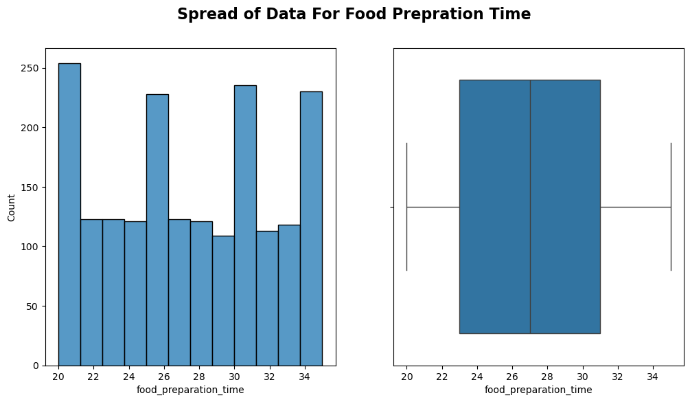

```python
#For numerical variable
fig, axes = plt.subplots(1, 2, figsize=(12, 6))  #adds 1 rows and 2 columns for the subplots
sns.histplot(data=foodhub,x='food_preparation_time',ax=axes[0])

sns.boxplot(data=foodhub,x='food_preparation_time',ax=axes[1])
plt.suptitle("Spread of Data For Food Prepration Time", fontsize=16, fontweight="bold")
plt.show()
```

#### Observations:

1. Data distribution is uniform with slight peak at regular interval.
2. 50% of the orders are prepared under 27mins.
3. No outliers in this variable.

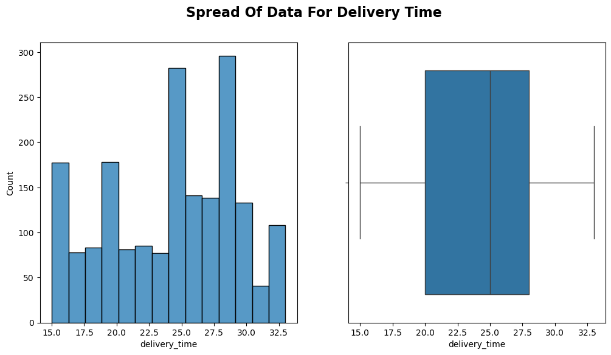

```python
#For numerical variable
fig,axes=plt.subplots(1,2,figsize=(12,6))
sns.histplot(data=foodhub,x='delivery_time',ax=axes[0])


sns.boxplot(data=foodhub,x='delivery_time',ax=axes[1])

plt.suptitle("Spread Of Data For Delivery Time", fontsize=16, fontweight="bold")
plt.show()
```

#### Observations:

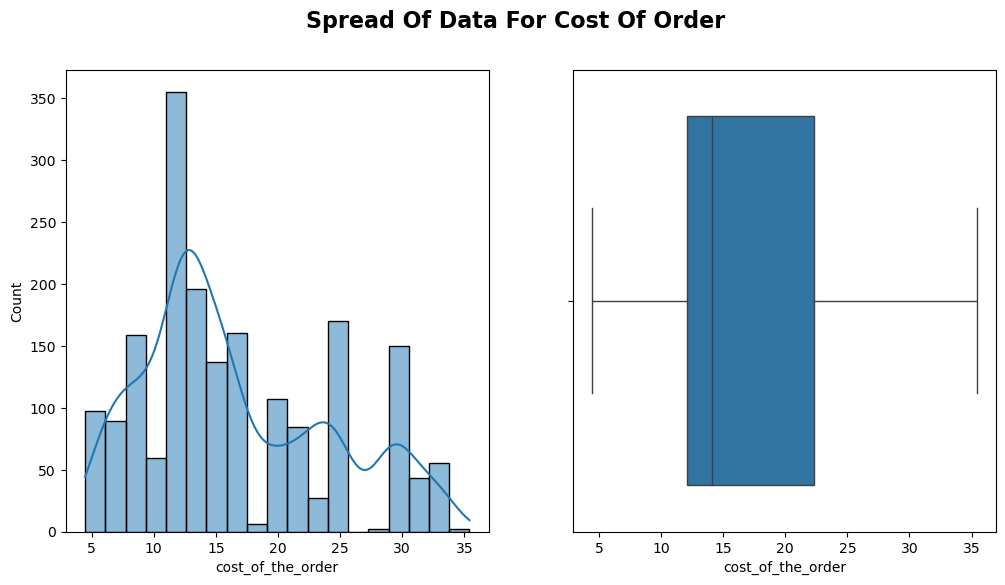

```python
#For numerical variable
fig,axes=plt.subplots(1,2,figsize=(12,6))
sns.histplot(foodhub,x='cost_of_the_order',kde=True,ax=axes[0])

sns.boxplot(foodhub,x='cost_of_the_order',ax=axes[1])
plt.suptitle("Spread Of Data For Cost Of Order", fontsize=16, fontweight="bold")
plt.show()
```

#### Observations:

1.It is slightly right skewed.  
2.Most of the orders are on lower end around 12 to $15 approximately.  
3.There are few customers who have paid on higher end(app 30 to 35)  
4.No outliers in this variable

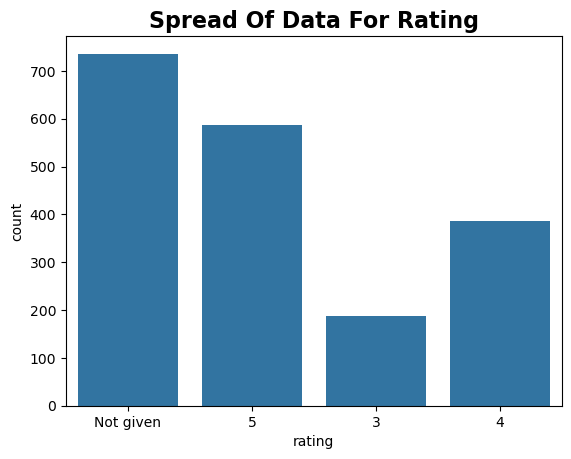

```python
#For categorical variable
sns.countplot(foodhub,x='rating')
plt.title("Spread Of Data For Rating",fontsize=16, fontweight="bold")
plt.show()
```

#### Observations:

1. Around 736 orders are not rated.
2. Other than that most of the orders have received 5 ratings.

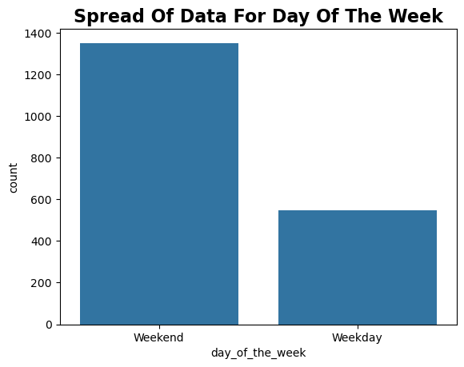

```python
#For categorical variable
sns.countplot(foodhub,x='day_of_the_week')
plt.title("Spread Of Data For Day Of The Week",fontsize=16, fontweight="bold")
plt.show()
```

#### Observations:

Number of orders are more during weekend than weekdays.

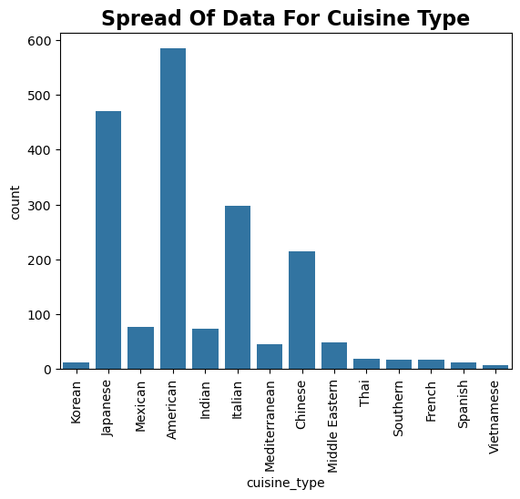

```python
sns.countplot(foodhub,x='cuisine_type')
plt.title("Spread Of Data For Cuisine Type",fontsize=16, fontweight="bold")
plt.xticks(rotation=90)
plt.show()
```

#### Observations:

1. American cuisine is ordered the most,followed by Japanese,Italian and Chinese.
2. Vietnamese is the least ordered cuisine.
3. It also good to note that Korean and Spanish are the second least ordered cuisine.

### **Question 7**: Which are the top 5 restaurants in terms of the number of orders received?

```python
#Lets check how many restaurants are in our data
foodhub['restaurant_name'].nunique #displays the total number of restaurants.
```

```
<bound method IndexOpsMixin.nunique of 0                                     Hangawi
1                   Blue Ribbon Sushi Izakaya
2                                 Cafe Habana
3                   Blue Ribbon Fried Chicken
4                            Dirty Bird to Go
                        ...
1893    Chipotle Mexican Grill $1.99 Delivery
1894                                The Smile
1895                        Blue Ribbon Sushi
1896                        Jack's Wife Freda
1897                        Blue Ribbon Sushi
Name: restaurant_name, Length: 1898, dtype: object>
```

```python
foodhub['restaurant_name'].value_counts().head(5).reset_index() #displays the first 5 rows
```

|  | restaurant_name | count |
| --- | --- | --- |
| 0 | Shake Shack | 219 |
| 1 | The Meatball Shop | 132 |
| 2 | Blue Ribbon Sushi | 119 |
| 3 | Blue Ribbon Fried Chicken | 96 |
| 4 | Parm | 68 |

```python
foodhub['restaurant_name'].value_counts().head(5).index #index will just pick the restaurants name and displays it.
```

```
Index(['Shake Shack', 'The Meatball Shop', 'Blue Ribbon Sushi',
       'Blue Ribbon Fried Chicken', 'Parm'],
      dtype='object', name='restaurant_name')
```

#### Observations:

Shake Shack, The Meatball Shop, Blue Ribbon Sushi,Blue Ribbon Fried Chicken, Parm are the top 5 restaurants which have received more number of orders.With Shake shack being the number 1 with 219 orders and The meatball shaop with 132 orders.

### **Question 8**: Which is the most popular cuisine on weekends?

```python
foodhub[foodhub['day_of_the_week']=='Weekend']['cuisine_type'].value_counts() #filters day of the week by weekend
```

```
cuisine_type
American          415
Japanese          335
Italian           207
Chinese           163
Mexican            53
Indian             49
Mediterranean      32
Middle Eastern     32
Thai               15
French             13
Korean             11
Southern           11
Spanish            11
Vietnamese          4
Name: count, dtype: int64
```

#### Observations:

American cuisine is most popular on weekends with 415 orders.Wile Vietnamese is least popular cuisine on weekends.

### **Question 9**: What percentage of the orders cost more than 20 dollars?

```python
order_above20=foodhub[foodhub['cost_of_the_order'] > 20] #displays all the orders greater than 20
per_order_above20=(len(order_above20)/len(foodhub['cost_of_the_order']))*100 #calculates the %
print("The percentage of orders which cost more than $20 is:",per_order_above20)
```

```
The percentage of orders which cost more than $20 is: 29.24130663856691
```

### **Question 10**: What is the mean order delivery time?

```python
foodhub['delivery_time'].mean()
```

```
24.161749209694417
```

#### Observations:

The mean order delivery time is 24.16mins,which indicates that users have received their food within approximately 24mins of placing their order.

### **Question 11:** The company has decided to give 20% discount vouchers to the top 3 most frequent customers. Find the IDs of these customers and the number of orders they placed.

```python
top_3_cust=foodhub['customer_id'].value_counts()
top_3_cust.head(3)
```

```
customer_id
52832    13
47440    10
83287     9
Name: count, dtype: int64
```

#### Observations:

Customer_id 52832 tops the list with total 13 orders followed by customer_id 47440 with 10 orders and customer_id 83287 with 9 orders.

### **Question 12**: Perform a multivariate analysis to explore relationships between the important variables in the dataset. (It is a good idea to explore relations between numerical variables as well as relations between numerical and categorical variables) [10 marks]

```python
#Lets check if Cuisine type effects other variables
```

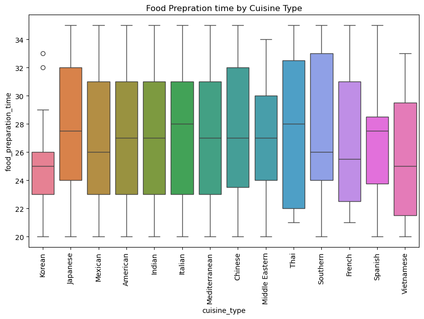

```python
plt.figure(figsize=(10,6))
sns.boxplot(x="cuisine_type", y="food_preparation_time",hue='cuisine_type', data=foodhub)
plt.xticks(rotation=90)
plt.title("Food Prepration time by Cuisine Type")
plt.show()
```

#### Observations:

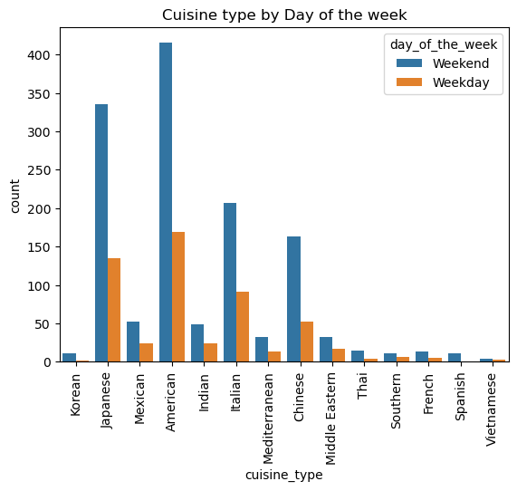

```python
#Relationship between cuisine type and day of the week
sns.countplot(data=foodhub, x='cuisine_type', hue='day_of_the_week')
plt.title("Cuisine type by Day of the week")
plt.xticks(rotation=90)
plt.show()
```

#### Observations:

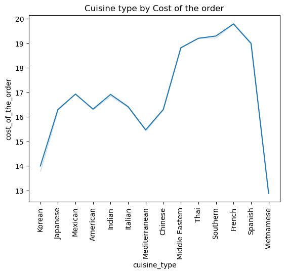

```python
#Relationship between cost of order and cuisine type.
sns.lineplot(data=foodhub, x='cuisine_type', y='cost_of_the_order', errorbar=('ci', False))
plt.title("Cuisine type by Cost of the order")
plt.xticks(rotation=90)
plt.show()
```

#### Observations:

1.Cost of the order is less for Vietnamese cuisine.  
2.French cuisine cost of order is more compared to all other cuisine.

```python
#Relationship between day of the week and delivery time
```

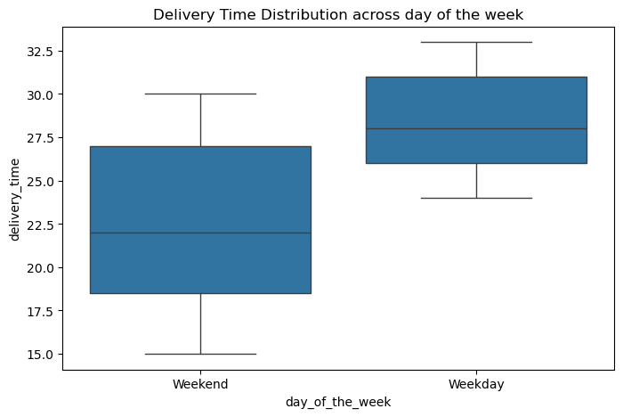

```python
plt.figure(figsize=(8,5))
sns.boxplot(data=foodhub, x="day_of_the_week", y="delivery_time")
plt.title("Delivery Time Distribution across day of the week")
plt.show()
```

#### Observations:

1.Food delivery on weekend takes less time, may be due to no rush hours. Food is delivered within 18 to 26mins.

2.Food delivery on weekdays take more time, may be due to rush hours. Food is delivered within 26 to 31mins.

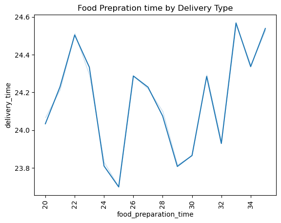

```python
#How does food preparation time effect delivery time
sns.lineplot(data=foodhub, x='food_preparation_time', y='delivery_time',errorbar=('ci',False))
plt.title("Food Prepration time by Delivery Type")
plt.xticks(rotation=90)
plt.show()
```

#### Observations:

Delivery time clearly doesnt depend on food preparation time.It could be influnsed by other factors such as traffic and distance.

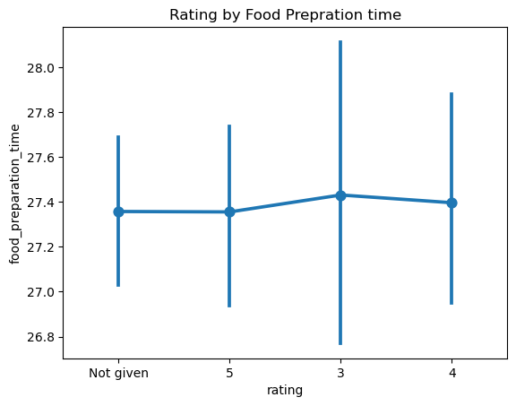

```python
#Relationship between between food preparation time and rating
sns.pointplot(data=foodhub,x='rating', y='food_preparation_time')
plt.title("Rating by Food Prepration time")
plt.show()
```

1.The average food preparation time remains contant almost across different ratings.  
2.Ratings do not seem to strongly influence food preparation time.

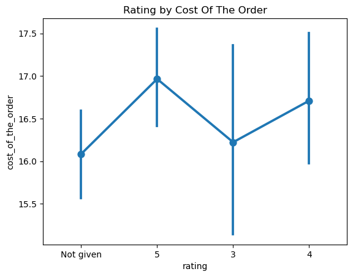

```python
#Relationship between cost of the order and rating
sns.pointplot(data=foodhub,x='rating', y='cost_of_the_order')
plt.title("Rating by Cost Of The Order")
plt.show()
```

#### Observations:

Orders with rating 5 ratings have the highest cost of order and ratings of 3 ratings show a slight dip.

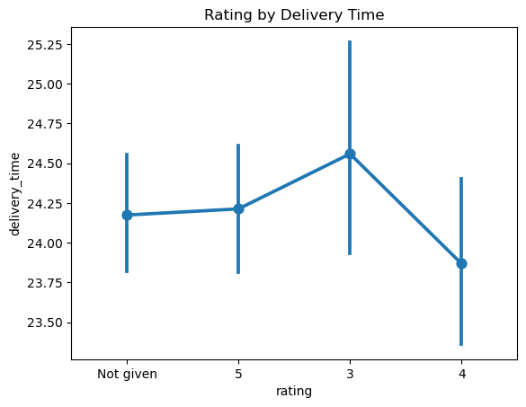

```python
#Relationship between delivery time and rating
sns.pointplot(data=foodhub,x='rating', y='delivery_time')
plt.title("Rating by Delivery Time")
plt.show()
```

#### Observation:

1. There is a relationship bwtween rating and delivery_time
2. Shorter and more consistent delivery times may lead to better ratings (rating 4).
3. Longer and more inconsistent delivery times tend to correlate with lower ratings (rating 3).

#### **Correlation by Heatmap**

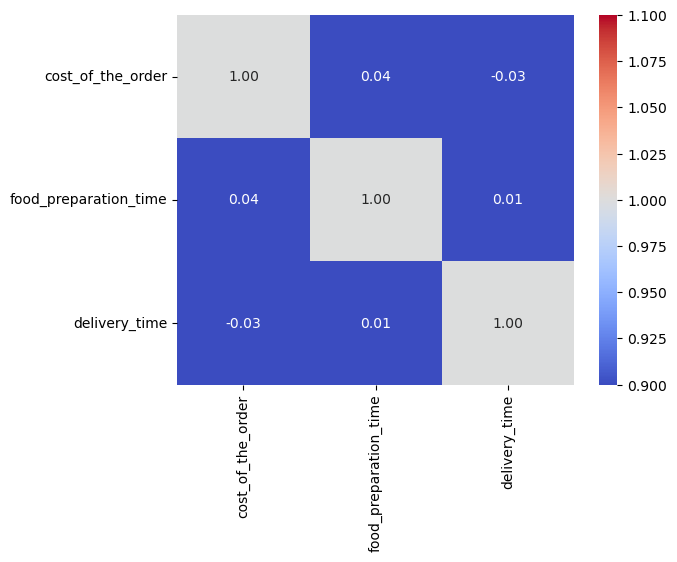

```python
sns.heatmap(foodhub[['cost_of_the_order','food_preparation_time','delivery_time']].corr(),vmin=1,vmax=1,annot=True,cbar=True,fmt='.2f',cmap='coolwarm')
plt.show()
```

#### Observations:

These variables have weak correlation with each other.